# wildfire_data_analysis_omer_bolukbasi

## 1 - Module Imports and Data Collection

```python
import pandas as pd
import numpy as np
from sklearn.model_selection import train_test_split
from sklearn.metrics import accuracy_score, precision_score, recall_score, f1_score
from sklearn.metrics import classification_report
from sklearn.preprocessing import MinMaxScaler, StandardScaler,LabelEncoder
from sklearn.decomposition import PCA
import sqlite3
from prophet import Prophet
from prophet.plot import add_changepoints_to_plot
import datetime as dt
from sklearn import linear_model
import xgboost as xgb
from sklearn.ensemble import RandomForestClassifier
from imblearn.over_sampling import SMOTE
import matplotlib.pyplot as plt
import seaborn as sns
import logging
import warnings
%matplotlib inline
warnings.filterwarnings('ignore')
pd.set_option('display.max_rows', None)
pd.set_option('display.max_columns', 500)
pd.set_option('display.width', 1000)
logger = logging.getLogger()
logger.setLevel(logging.CRITICAL)
```

```python
# Connect to the sqlite db file and retrieve data as Pandas data frame.
cnx = sqlite3.connect('archive/FPA_FOD_20170508.sqlite')
sql = "select * from fires"
df = pd.read_sql_query(sql, cnx)
```

```python
df.head()
```

|  | OBJECTID | FOD_ID | FPA_ID | SOURCE_SYSTEM_TYPE | SOURCE_SYSTEM | NWCG_REPORTING_AGENCY | NWCG_REPORTING_UNIT_ID | NWCG_REPORTING_UNIT_NAME | SOURCE_REPORTING_UNIT | SOURCE_REPORTING_UNIT_NAME | LOCAL_FIRE_REPORT_ID | LOCAL_INCIDENT_ID | FIRE_CODE | FIRE_NAME | ICS_209_INCIDENT_NUMBER | ICS_209_NAME | MTBS_ID | MTBS_FIRE_NAME | COMPLEX_NAME | FIRE_YEAR | DISCOVERY_DATE | DISCOVERY_DOY | DISCOVERY_TIME | STAT_CAUSE_CODE | STAT_CAUSE_DESCR | CONT_DATE | CONT_DOY | CONT_TIME | FIRE_SIZE | … |
| --- | --- | --- | --- | --- | --- | --- | --- | --- | --- | --- | --- | --- | --- | --- | --- | --- | --- | --- | --- | --- | --- | --- | --- | --- | --- | --- | --- | --- | --- | --- |
| 0 | 1 | 1 | FS-1418826 | FED | FS-FIRESTAT | FS | USCAPNF | Plumas National Forest | 0511 | Plumas National Forest | 1 | PNF-47 | BJ8K | FOUNTAIN | None | None | None | None | None | 2005 | 2453403.5 | 33 | 1300 | 9.0 | Miscellaneous | 2453403.5 | 33.0 | 1730 | 0.10 | … |
| 1 | 2 | 2 | FS-1418827 | FED | FS-FIRESTAT | FS | USCAENF | Eldorado National Forest | 0503 | Eldorado National Forest | 13 | 13 | AAC0 | PIGEON | None | None | None | None | None | 2004 | 2453137.5 | 133 | 0845 | 1.0 | Lightning | 2453137.5 | 133.0 | 1530 | 0.25 | … |
| 2 | 3 | 3 | FS-1418835 | FED | FS-FIRESTAT | FS | USCAENF | Eldorado National Forest | 0503 | Eldorado National Forest | 27 | 021 | A32W | SLACK | None | None | None | None | None | 2004 | 2453156.5 | 152 | 1921 | 5.0 | Debris Burning | 2453156.5 | 152.0 | 2024 | 0.10 | … |
| 3 | 4 | 4 | FS-1418845 | FED | FS-FIRESTAT | FS | USCAENF | Eldorado National Forest | 0503 | Eldorado National Forest | 43 | 6 | None | DEER | None | None | None | None | None | 2004 | 2453184.5 | 180 | 1600 | 1.0 | Lightning | 2453189.5 | 185.0 | 1400 | 0.10 | … |
| 4 | 5 | 5 | FS-1418847 | FED | FS-FIRESTAT | FS | USCAENF | Eldorado National Forest | 0503 | Eldorado National Forest | 44 | 7 | None | STEVENOT | None | None | None | None | None | 2004 | 2453184.5 | 180 | 1600 | 1.0 | Lightning | 2453189.5 | 185.0 | 1200 | 0.10 | … |

## 2 - Answers to the questions

### A - Have wildfires become more or less frequent over time?

In order to find frequency of fires, daily, monthly and yearly counts will be extracted from the time-series data. For the trend and seasonality detection, Meta's fbprophet module will be used.

#### EDA and Feature Engineering

```python
# Check NA values in features of interest.
df_interest = df[["FIRE_YEAR","DISCOVERY_DOY","DISCOVERY_TIME","CONT_DOY","CONT_TIME","STAT_CAUSE_CODE","STAT_CAUSE_DESCR","FIRE_SIZE","LATITUDE","LONGITUDE","STATE","COUNTY","FIPS_NAME","DISCOVERY_DATE"]]
df_interest.isna().sum()
```

```
FIRE_YEAR                0
DISCOVERY_DOY            0
DISCOVERY_TIME      882638
CONT_DOY            891531
CONT_TIME           972173
STAT_CAUSE_CODE          0
STAT_CAUSE_DESCR         0
FIRE_SIZE                0
LATITUDE                 0
LONGITUDE                0
STATE                    0
COUNTY              678148
FIPS_NAME           678148
DISCOVERY_DATE           0
dtype: int64
```

County feature has many NA's. This needs to be handled for the second question.

```python
# Check and remove duplicate rows.
print(f"Number of removed duplicate rows: {df_interest.duplicated().sum()}")
df_interest = df_interest.drop_duplicates()
```

```
Number of removed duplicate rows: 3525
```

```python
# Check data values
print(df_interest.STATE.unique())
print(df_interest.COUNTY.unique())
```

```
['CA' 'NM' 'OR' 'NC' 'WY' 'CO' 'WA' 'MT' 'UT' 'AZ' 'SD' 'AR' 'NV' 'ID'
 'MN' 'TX' 'FL' 'SC' 'LA' 'OK' 'KS' 'MO' 'NE' 'MI' 'KY' 'OH' 'IN' 'VA'
 'IL' 'TN' 'GA' 'AK' 'ND' 'WV' 'WI' 'AL' 'NH' 'PA' 'MS' 'ME' 'VT' 'NY'
 'IA' 'DC' 'MD' 'CT' 'MA' 'NJ' 'HI' 'DE' 'PR' 'RI']
['63' '61' '17' ... 'Oahu' 'Molokaii' 'Lanai']
```

County values have numeric FIPS codes and also word format. So, instead of selecting COUNTY feature, FIPS_NAME is selected for the second question.(Also some counties in COUNTY feature are misstyped like Maui and Mauii)

```python
# Convert Julian date format into Gregorian date format.
df_interest["combined_date_dis"] = df_interest["FIRE_YEAR"]*1000 + df_interest["DISCOVERY_DOY"]
df_interest["combined_date_dis"] = pd.to_datetime(df_interest["combined_date_dis"], format = "%Y%j")
df_interest = df_interest.set_index("combined_date_dis")
df_interest.head()
```

| combined_date_dis | FIRE_YEAR | DISCOVERY_DOY | DISCOVERY_TIME | CONT_DOY | CONT_TIME | STAT_CAUSE_CODE | STAT_CAUSE_DESCR | FIRE_SIZE | LATITUDE | LONGITUDE | STATE | COUNTY | FIPS_NAME | DISCOVERY_DATE |
| --- | --- | --- | --- | --- | --- | --- | --- | --- | --- | --- | --- | --- | --- | --- |
| 2005-02-02 | 2005 | 33 | 1300 | 33.0 | 1730 | 9.0 | Miscellaneous | 0.10 | 40.036944 | -121.005833 | CA | 63 | Plumas | 2453403.5 |
| 2004-05-12 | 2004 | 133 | 0845 | 133.0 | 1530 | 1.0 | Lightning | 0.25 | 38.933056 | -120.404444 | CA | 61 | Placer | 2453137.5 |
| 2004-05-31 | 2004 | 152 | 1921 | 152.0 | 2024 | 5.0 | Debris Burning | 0.10 | 38.984167 | -120.735556 | CA | 17 | El Dorado | 2453156.5 |
| 2004-06-28 | 2004 | 180 | 1600 | 185.0 | 1400 | 1.0 | Lightning | 0.10 | 38.559167 | -119.913333 | CA | 3 | Alpine | 2453184.5 |
| 2004-06-28 | 2004 | 180 | 1600 | 185.0 | 1200 | 1.0 | Lightning | 0.10 | 38.559167 | -119.933056 | CA | 3 | Alpine | 2453184.5 |

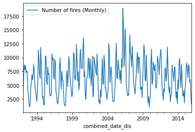

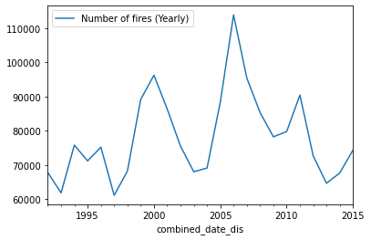

```python
# Examine monthly and yearly counts of fires.
monthly_trend = df_interest.groupby(pd.Grouper(freq='M')).count()[["FIRE_YEAR"]]
monthly_trend.columns = ["Number of fires (Monthly)"]
monthly_trend.plot()

yearly_trend = df_interest.groupby(pd.Grouper(freq='Y')).count()[["FIRE_YEAR"]]
yearly_trend.columns = ["Number of fires (Yearly)"]
yearly_trend.plot()
```

```python
# Implement fbprophet module to find the trends and trend change points.
# Convert the inputs into daily sum and change the column names to apply fpprophet.
daily_sum = df_interest.groupby(pd.Grouper(freq='D')).count()[["FIRE_YEAR"]]
daily_sum = daily_sum.reset_index()
daily_sum.columns = ["ds","y"]
daily_sum.head()
```

|  | ds | y |
| --- | --- | --- |
| 0 | 1992-01-01 | 129 |
| 1 | 1992-01-02 | 46 |
| 2 | 1992-01-03 | 43 |
| 3 | 1992-01-04 | 68 |
| 4 | 1992-01-05 | 44 |

```python
def prophet_model(time_series_df,
                  growth = "linear",
                  interval_width=0.95,
                  changepoint_range=0.8,
                  changepoint_prior_scale=1,
                  seasonality_mode='multiplicative',
                  n_changepoints=50,
                  periods=36,
                  freq='M',
                  holidays_prior_scale = 0.0,
                  yearly_seasonality = True,
                  daily_seasonality = False,
                  weekly_seasonality = False):
    """This function is used to implement Fbprophet on the given time-series data. The inputs are set with
    their default values. Parameter descriptions are in the following source:
    https://cran.r-project.org/web/packages/prophet/prophet.pdf"""
    # Convert column names as proposed
    df_prophet = time_series_df.reset_index()
    df_prophet.columns = ["ds","y"]
    # Fit the model with the given parameters.
    m = Prophet(growth=growth,interval_width=interval_width, changepoint_range=changepoint_range, changepoint_prior_scale=changepoint_prior_scale, seasonality_mode=seasonality_mode, n_changepoints=n_changepoints,yearly_seasonality=yearly_seasonality,daily_seasonality=daily_seasonality,weekly_seasonality=weekly_seasonality)
    m.fit(df_prophet)
    # Make future data frame to retrieve trends.
    future = m.make_future_dataframe(periods=periods, freq=freq)
    forecast = m.predict(future)
    return m,forecast
```

[output not shown]

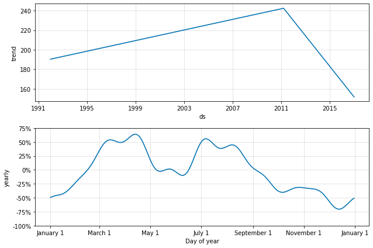

```python
# Extract weekly, monthly and yearly trends.
m,forecast = prophet_model(daily_sum.set_index("ds"),periods=1, freq='Y',n_changepoints=1)
m.plot_components(forecast);
```

#### By looking the at the trends, the question can be answered yearly and overal.

- In the yearly averages, spring and summer months have higest fire rates.(March, April, July, August)
- Finally, in the overal trend, we can conclude that up to 2011 the fires have become more frequent. And after 2011, the fires have become less frequent.

In order to create an automated answer we need to extract the trend change points and calculate slopes of the trends.

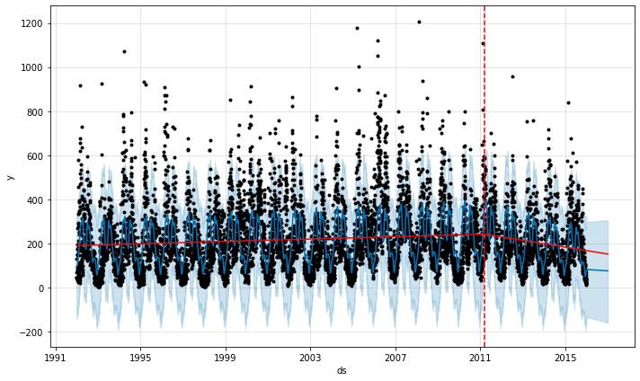

```python
# Obtain trend change points.
fig = m.plot(forecast)
a = add_changepoints_to_plot(fig.gca(), m, forecast)
```

```python
# Divide the dataset into portions lower and upper of the change point.
trend = forecast[["ds","trend"]]
lower_portion = trend[(trend["ds"]<m.changepoints.to_list()[0])]
upper_portion = trend[(trend["ds"]>m.changepoints.to_list()[0])]

# Calculate slopes with using linear Regression.
reg_lower = linear_model.LinearRegression()
reg_upper = linear_model.LinearRegression()

reg_lower.fit(pd.to_datetime(lower_portion['ds']).map(dt.datetime.toordinal).values.reshape(-1, 1), lower_portion['trend'].values)
reg_upper.fit(pd.to_datetime(upper_portion['ds']).map(dt.datetime.toordinal).values.reshape(-1, 1), upper_portion['trend'].values)

print(f"Slope before changepoint({m.changepoints.to_list()[0]}): {reg_lower.coef_}")
print(f"Slope before changepoint({m.changepoints.to_list()[0]}): {reg_upper.coef_}")
```

```
Slope before changepoint(2011-03-13 00:00:00): [0.00744251]
Slope before changepoint(2011-03-13 00:00:00): [-0.04283992]
```

We can use the above calculations to develop automation for this question. If the slope before changepoint is positive that means the fires have become more frequent up to the changepoint, and vise-wersa is also true.

### B - What counties are the most and least fire-prone?

Fire Durations, Fire Sizes and Fire Counts can give idea about the proneness of the counties. Fire Counts are calculated in the previous question. Fire sizes are already exist in the dataset. Fire duration will be calculated. In order to find a final alignment between counties these features will be reduced to one with using Princaipal Component Analysis.

#### EDA and Feature Engineering

```python
# County values have numeric FIPS codes and also word format. So, instead of selecting COUNTY
# feature, FIPS_NAME is assigned as county.
df_interest["COUNTY"] = df_interest["FIPS_NAME"]
```

```python
# Exctract monthly count of fires for each county.
df_monthly = df_interest.groupby(["STATE","COUNTY",pd.Grouper(freq="M")]).count().FIRE_YEAR.reset_index()
df_monthly = df_monthly.rename(columns={"FIRE_YEAR": "fire_count"})
df_monthly["combined_date_dis"] = df_monthly.combined_date_dis.dt.strftime('%Y-%m')
df_monthly.head()
```

|  | STATE | COUNTY | combined_date_dis | fire_count |
| --- | --- | --- | --- | --- |
| 0 | AK | Anchorage | 2007-05 | 1 |
| 1 | AK | Anchorage | 2010-07 | 1 |
| 2 | AK | Bethel | 2014-06 | 1 |
| 3 | AK | Bethel | 2015-05 | 1 |
| 4 | AK | Bethel | 2015-06 | 15 |

```python
# Since DISCOVERY_TIME feature has lots of NA values, a new dataframe will be created for the this question.
df_duration = df_interest.dropna()
df_duration = df_duration.drop_duplicates()
# Convert Julian time.
df_duration["combined_date_dis"] = df_duration["FIRE_YEAR"]*1000 + df_duration["DISCOVERY_DOY"]
df_duration["combined_date_dis"] = pd.to_datetime(df_duration["combined_date_dis"], format = "%Y%j")
df_duration["combined_date_dis"] = df_duration.combined_date_dis.astype(str) + " " + df_duration.DISCOVERY_TIME.str[:2] + ":" + df_duration.DISCOVERY_TIME.str[2:]
df_duration["combined_date_dis"] = pd.to_datetime(df_duration["combined_date_dis"])
df_duration["combined_date_con"] = df_duration["FIRE_YEAR"]*1000 + df_duration["CONT_DOY"]
df_duration["combined_date_con"] = pd.to_datetime(df_duration["combined_date_con"], format = "%Y%j",errors="ignore")
df_duration["combined_date_con"] = df_duration.combined_date_con.astype(str) + " " + df_duration.CONT_TIME.str[:2] + ":" + df_duration.CONT_TIME.str[2:]
df_duration["combined_date_con"] = pd.to_datetime(df_duration["combined_date_con"],errors="coerce")
df_duration["duration"] = None
# Calculate Fire Durations from the difference of Discovery and Control times.
df_duration.loc[df_duration['combined_date_con'].notna(), 'duration'] = (df_duration["combined_date_con"] - df_duration["combined_date_dis"]).dt.seconds/60
df_duration = df_duration.set_index("combined_date_dis")
df_duration["duration"] = df_duration.duration.astype(float)
df_duration.head()
```

| combined_date_dis | FIRE_YEAR | DISCOVERY_DOY | DISCOVERY_TIME | CONT_DOY | CONT_TIME | STAT_CAUSE_CODE | STAT_CAUSE_DESCR | FIRE_SIZE | LATITUDE | LONGITUDE | STATE | COUNTY | FIPS_NAME | DISCOVERY_DATE | combined_date_con | duration |
| --- | --- | --- | --- | --- | --- | --- | --- | --- | --- | --- | --- | --- | --- | --- | --- | --- |
| 2005-02-02 13:00:00 | 2005 | 33 | 1300 | 33.0 | 1730 | 9.0 | Miscellaneous | 0.10 | 40.036944 | -121.005833 | CA | Plumas | Plumas | 2453403.5 | 2005-02-02 17:30:00 | 270.0 |
| 2004-05-12 08:45:00 | 2004 | 133 | 0845 | 133.0 | 1530 | 1.0 | Lightning | 0.25 | 38.933056 | -120.404444 | CA | Placer | Placer | 2453137.5 | 2004-05-12 15:30:00 | 405.0 |
| 2004-05-31 19:21:00 | 2004 | 152 | 1921 | 152.0 | 2024 | 5.0 | Debris Burning | 0.10 | 38.984167 | -120.735556 | CA | El Dorado | El Dorado | 2453156.5 | 2004-05-31 20:24:00 | 63.0 |
| 2004-06-28 16:00:00 | 2004 | 180 | 1600 | 185.0 | 1400 | 1.0 | Lightning | 0.10 | 38.559167 | -119.913333 | CA | Alpine | Alpine | 2453184.5 | 2004-07-03 14:00:00 | 1320.0 |
| 2004-06-28 16:00:00 | 2004 | 180 | 1600 | 185.0 | 1200 | 1.0 | Lightning | 0.10 | 38.559167 | -119.933056 | CA | Alpine | Alpine | 2453184.5 | 2004-07-03 12:00:00 | 1200.0 |

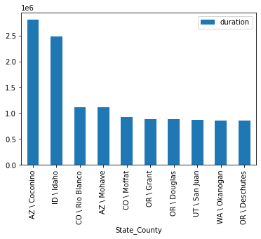

```python
# Combine State and Counties
df_duration["State_County"] = df_duration.STATE + " \\ " + df_duration.FIPS_NAME

# Retrieve the top 10 counties in terms of total fire duration.
df_duration.groupby(["State_County"]).sum().reset_index().sort_values(by="duration",ascending=False).head(10)[["State_County","duration"]].plot.bar(x = "State_County",y = "duration")
```

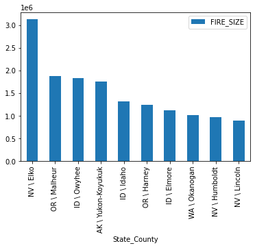

```python
# Retrieve the top 10 counties in terms of total fire size.
df_duration.groupby(["State_County"]).sum().reset_index().sort_values(by="FIRE_SIZE",ascending=False).head(10)[["State_County","FIRE_SIZE"]].plot.bar(x = "State_County",y = "FIRE_SIZE")
```

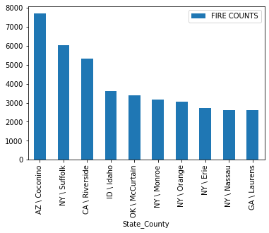

```python
# Retrieve the top 10 counties in terms of fire counts.
df_fire_counts = df_duration.groupby(["State_County"]).count().reset_index()[["State_County","FIRE_YEAR"]].sort_values(by="FIRE_YEAR",ascending=False)
df_fire_counts.columns = ["State_County","FIRE COUNTS"]
df_fire_counts.head(10).plot.bar(x = "State_County",y = "FIRE COUNTS")
```

From the above graphs, the following results are obtained:

- In terms of Duration, the counties Coconino(AZ) and Idaho(ID) have the highest total duration of fire.
- In terms of Fire Size, the counties Elco(NV) has the highest total size of fire.
- In terms of Fire Counts, Coconino(AZ) and Suffolk(NY) have the highest total duration of fire.

A resultant final metric that is a kind of linear combinations of this three features can be obtained with using Principal Component Analysis(PCA). PCA basically implement Eigenvalues Decomposition on the covariance matrix of the input data and extracts the linear combinations of the input features and sorts these components based on their variences. The principal component that has the highest varience, also has the highest information representation of the dataset. So, this component can be used as a common metric of pronenes for the counties.

```python
# Combine the metrics into the same data frame.
df_fire_size = df_duration.groupby(["State_County"]).sum().reset_index()[["State_County","FIRE_SIZE"]]
df_fire_duration = df_duration.groupby(["State_County"]).sum().reset_index()[["State_County","duration"]]
df_proneness = df_fire_counts.merge(df_fire_size,on="State_County",how="inner").merge(df_fire_duration,on="State_County",how="inner")
df_proneness.head()
```

|  | State_County | FIRE COUNTS | FIRE_SIZE | duration |
| --- | --- | --- | --- | --- |
| 0 | AZ \ Coconino | 7698 | 356910.57 | 2810174.0 |
| 1 | NY \ Suffolk | 6047 | 2714.95 | 84448.0 |
| 2 | CA \ Riverside | 5338 | 197356.57 | 330424.0 |
| 3 | ID \ Idaho | 3598 | 1316621.10 | 2477468.0 |
| 4 | OK \ McCurtain | 3397 | 49528.50 | 309467.0 |

```python
#  Before implementing the dataset to PCA, the values must be standartized.
scaler = StandardScaler()
scaled = pd.DataFrame(scaler.fit_transform(df_proneness.drop("State_County",axis=1).values),columns = df_proneness.drop("State_County",axis=1).columns)
scaled.head()
```

|  | FIRE COUNTS | FIRE_SIZE | duration |
| --- | --- | --- | --- |
| 0 | 17.272051 | 2.807717 | 22.082915 |
| 1 | 13.451203 | -0.168032 | 0.325851 |
| 2 | 11.810391 | 1.467236 | 2.289260 |
| 3 | 7.783573 | 10.870655 | 19.427217 |
| 4 | 7.318406 | 0.225269 | 2.121979 |

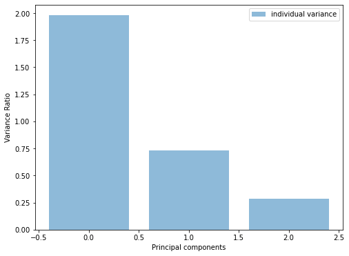

```python
# Implement PCA and calculate the variences of the principal components.
pca = PCA()
pca.fit_transform(scaled)
pca_variance = pca.explained_variance_

# Visualize the variance ratio of all principle components.
plt.figure(figsize=(8, 6))
plt.bar(range(3), pca_variance, alpha=0.5, align='center', label='individual variance')
plt.legend()
plt.ylabel('Variance Ratio')
plt.xlabel('Principal components')
plt.show()
```

The first principal component's varience is significantly higher than the rest, so the first one has the highest information related with the dataset and can be used as proneness metric.

```python
# Retrieve the component that has the highest varience.
pca1 = PCA(n_components=1)
pca1.fit(scaled)
x_1d = pca1.transform(scaled)
df_proneness["proneness"] = x_1d

# Print the counties that are the least and the most fire-prone.
print("Most Fire-Prone Counties: \n",df_proneness.sort_values(by="proneness",ascending=False)[["State_County","proneness"]].head(3),"\n")
print("Least Fire-Prone Counties: \n",df_proneness.sort_values(by="proneness",ascending=False)[["State_County","proneness"]].tail(3))
```

```
Most Fire-Prone Counties:
      State_County  proneness
0   AZ \ Coconino  25.768307
3      ID \ Idaho  22.408293
21      NV \ Elko  19.071113

Least Fire-Prone Counties:
             State_County  proneness
2423     KY \ Washington  -0.635862
2380  AK \ Kodiak Island  -0.635865
2354         IA \ Marion  -0.635866
```

According to final results, Coconino, Idaho and Elko are the most fire-prone counties, while Washington, Kodiak Island and Marion are the least fire-prone counties.

### C - Given the size, location and date, can you predict the cause of a fire wildfire?

In order to develop a model that can predict the cause of fire, all related features needs to be extracted from the dataset. These features are the days of the week, month of the year and fire duration.

#### EDA and Feature Engineering

```python
# Arrange the dates for the Model Data Frame.
df_model = df[["FIRE_YEAR","DISCOVERY_DOY","DISCOVERY_TIME","DISCOVERY_DATE","CONT_DOY","CONT_TIME","STAT_CAUSE_CODE","STAT_CAUSE_DESCR","FIRE_SIZE","LATITUDE","LONGITUDE","STATE","FIPS_NAME"]]
df_model = df_model.drop_duplicates()
df_model["combined_date_dis"] = df_model["FIRE_YEAR"]*1000 + df_model["DISCOVERY_DOY"]
df_model["combined_date_dis"] = pd.to_datetime(df_model["combined_date_dis"], format = "%Y%j")
df_model["combined_date_dis"] = df_model.combined_date_dis.astype(str) + " " + df_model.DISCOVERY_TIME.str[:2] + ":" + df_model.DISCOVERY_TIME.str[2:]
df_model["combined_date_dis"] = pd.to_datetime(df_model["combined_date_dis"])
df_model["combined_date_con"] = df_model["FIRE_YEAR"]*1000 + df_model["CONT_DOY"]
df_model["combined_date_con"] = pd.to_datetime(df_model["combined_date_con"], format = "%Y%j",errors="ignore")
df_model["combined_date_con"] = df_model.combined_date_con.astype(str) + " " + df_model.CONT_TIME.str[:2] + ":" + df_model.CONT_TIME.str[2:]
df_model["combined_date_con"] = pd.to_datetime(df_model["combined_date_con"],errors="coerce")
# Calculate the durations of the fire from substraction of discovery and control time.
df_model["duration"] = None
df_model.loc[df_model['combined_date_con'].notna(), 'duration'] = (df_model["combined_date_con"] - df_model["combined_date_dis"]).dt.seconds/60
# Extract week day and the month for each fire.
df_model["week_day"] = df_model.combined_date_dis.dt.weekday
df_model["month"] = df_model.combined_date_dis.dt.month
df_model = df_model.set_index("combined_date_dis")
df_model["duration"] = df_model.duration.astype(float)
df_model.head()
```

| combined_date_dis | FIRE_YEAR | DISCOVERY_DOY | DISCOVERY_TIME | DISCOVERY_DATE | CONT_DOY | CONT_TIME | STAT_CAUSE_CODE | STAT_CAUSE_DESCR | FIRE_SIZE | LATITUDE | LONGITUDE | STATE | FIPS_NAME | combined_date_con | duration | week_day | month |
| --- | --- | --- | --- | --- | --- | --- | --- | --- | --- | --- | --- | --- | --- | --- | --- | --- | --- |
| 2005-02-02 13:00:00 | 2005 | 33 | 1300 | 2453403.5 | 33.0 | 1730 | 9.0 | Miscellaneous | 0.10 | 40.036944 | -121.005833 | CA | Plumas | 2005-02-02 17:30:00 | 270.0 | 2.0 | 2.0 |
| 2004-05-12 08:45:00 | 2004 | 133 | 0845 | 2453137.5 | 133.0 | 1530 | 1.0 | Lightning | 0.25 | 38.933056 | -120.404444 | CA | Placer | 2004-05-12 15:30:00 | 405.0 | 2.0 | 5.0 |
| 2004-05-31 19:21:00 | 2004 | 152 | 1921 | 2453156.5 | 152.0 | 2024 | 5.0 | Debris Burning | 0.10 | 38.984167 | -120.735556 | CA | El Dorado | 2004-05-31 20:24:00 | 63.0 | 0.0 | 5.0 |
| 2004-06-28 16:00:00 | 2004 | 180 | 1600 | 2453184.5 | 185.0 | 1400 | 1.0 | Lightning | 0.10 | 38.559167 | -119.913333 | CA | Alpine | 2004-07-03 14:00:00 | 1320.0 | 0.0 | 6.0 |
| 2004-06-28 16:00:00 | 2004 | 180 | 1600 | 2453184.5 | 185.0 | 1200 | 1.0 | Lightning | 0.10 | 38.559167 | -119.933056 | CA | Alpine | 2004-07-03 12:00:00 | 1200.0 | 0.0 | 6.0 |

```python
# Check and remove the duplicated independent variables("FIRE_YEAR","DISCOVERY_DOY","DISCOVERY_TIME",
#"DISCOVERY_DATE","CONT_DOY","CONT_TIME","FIRE_SIZE","LATITUDE","LONGITUDE","STATE","FIPS_NAME") that
#have different corresponding dependent variable values (STAT_CAUSE_DESCR) in different rows
df_duplicated_independent_records = df_model.drop_duplicates().groupby(["FIRE_YEAR","DISCOVERY_DOY","DISCOVERY_TIME","DISCOVERY_DATE","CONT_DOY","CONT_TIME","FIRE_SIZE","LATITUDE","LONGITUDE","STATE","FIPS_NAME","duration","week_day","month"]).count().reset_index().query('STAT_CAUSE_DESCR != 1')[["FIRE_YEAR","DISCOVERY_DOY","DISCOVERY_TIME","DISCOVERY_DATE","CONT_DOY","CONT_TIME","FIRE_SIZE","LATITUDE","LONGITUDE","STATE","FIPS_NAME","duration","week_day","month"]]
print(f"Number of removed duplicated independent variable rows that have different dependent variable values: {df_duplicated_independent_records.count()[0]}")
df_model = pd.merge(df_model,df_duplicated_independent_records,on=["FIRE_YEAR","DISCOVERY_DOY","DISCOVERY_TIME","DISCOVERY_DATE","CONT_DOY","CONT_TIME","FIRE_SIZE","LATITUDE","LONGITUDE","STATE","FIPS_NAME","duration","week_day","month"],how="outer",indicator="i").query('i == "left_only"').drop("i",axis=1)
```

```
Number of removed duplicated independent variable rows that have different dependent variable values: 15
```

In 15 rows, there are duplicated rows in terms of independent variables("FIRE_YEAR", "DISCOVERY_DOY", "DISCOVERY_TIME", "DISCOVERY_DATE", "CONT_DOY", "CONT_TIME", "FIRE_SIZE", "LATITUDE","LONGITUDE","STATE","FIPS_NAME") that have different labels in dependent variable(STAT_CAUSE_DESCR). These rows are deleted.

```python
# Calculate the correlations among numerical features.
cat=['STATE','FIPS_NAME',"week_day","month"]
num=['FIRE_YEAR',"DISCOVERY_DOY","DISCOVERY_TIME","DISCOVERY_DATE","CONT_DOY","CONT_TIME","FIRE_SIZE","LATITUDE","LONGITUDE","duration","week_day","month"]
corr_df=df_model[num]
cor= corr_df.corr(method='pearson')
cor
```

|  | FIRE_YEAR | DISCOVERY_DOY | DISCOVERY_DATE | CONT_DOY | FIRE_SIZE | LATITUDE | LONGITUDE | duration | week_day | month |
| --- | --- | --- | --- | --- | --- | --- | --- | --- | --- | --- |
| FIRE_YEAR | 1.000000 | -0.008502 | 0.999316 | -0.005320 | 0.007035 | 0.000733 | 0.014556 | -0.003942 | 0.002526 | -0.009272 |
| DISCOVERY_DOY | -0.008502 | 1.000000 | 0.028492 | 0.994452 | 0.005814 | 0.145636 | -0.242574 | 0.138805 | -0.016023 | 0.994603 |
| DISCOVERY_DATE | 0.999316 | 0.028492 | 1.000000 | 0.025693 | 0.007247 | 0.006119 | 0.005579 | 0.000434 | 0.002014 | 0.022471 |
| CONT_DOY | -0.005320 | 0.994452 | 0.025693 | 1.000000 | 0.023477 | 0.165181 | -0.279337 | 0.153505 | -0.014439 | 0.988984 |
| FIRE_SIZE | 0.007035 | 0.005814 | 0.007247 | 0.023477 | 1.000000 | 0.038907 | -0.039818 | 0.047936 | -0.000625 | 0.006552 |
| LATITUDE | 0.000733 | 0.145636 | 0.006119 | 0.165181 | 0.038907 | 1.000000 | -0.354075 | 0.151054 | 0.006980 | 0.154152 |
| LONGITUDE | 0.014556 | -0.242574 | 0.005579 | -0.279337 | -0.039818 | -0.354075 | 1.000000 | -0.327357 | 0.000916 | -0.265762 |
| duration | -0.003942 | 0.138805 | 0.000434 | 0.153505 | 0.047936 | 0.151054 | -0.327357 | 1.000000 | -0.002568 | 0.138617 |
| week_day | 0.002526 | -0.016023 | 0.002014 | -0.014439 | -0.000625 | 0.006980 | 0.000916 | -0.002568 | 1.000000 | -0.015899 |
| month | -0.009272 | 0.994603 | 0.022471 | 0.988984 | 0.006552 | 0.154152 | -0.265762 | 0.138617 | -0.015899 | 1.000000 |

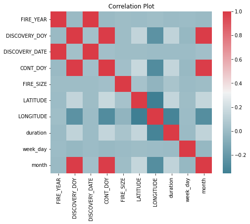

```python
# Visualize the pair-wise correlations.
fig, ax =plt.subplots(figsize=(8, 6))
plt.title("Correlation Plot")
sns.heatmap(cor, mask=np.zeros_like(cor, dtype=np.bool), cmap=sns.diverging_palette(220, 10, as_cmap=True),
            square=True, ax=ax)
plt.show()
```

Very strong correlations are exist between DISCOVERY_DOY,CONT_DOY, DISCOVERY_DATE,FIRE_YEAR. In order to prevent data redundancy, DISCOVERY_DATE and CONT_DOY can be removed from the training data. Also the correlations between LONGTITUDE and duration and month are interesting. It might be the effect of the climate change related with the longtitude.

```python
# Drop DISCOVERY_DATE, DISCOVERY_DOY and CONT_DOY
df_model = df_model.drop(["DISCOVERY_DATE","CONT_DOY","DISCOVERY_DOY"],axis=1)
```

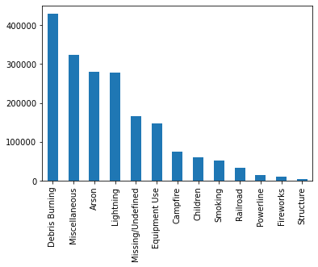

```python
# Check if the data is balanced in terms of the STAT_CAUSE_DESCR labels.
df_model["STAT_CAUSE_DESCR"].value_counts().plot.bar()
```

```python
# Calculate the rate of the category that has highest counts.
(df_model.query('STAT_CAUSE_DESCR == "Debris Burning"').count().STAT_CAUSE_DESCR / df_model.count().STAT_CAUSE_DESCR ) * 100
```

```
22.853544233388103
```

The data is so unbalanced. Some over or under sampling techniques are required to balance the data. Also the rate of the category(Debris Burning) that has the highest counts is %23. So, after the completing the modeling, the accuracy rate of the model must be at least %23.

Before implementing the data to the models, the nominal categorical values must be converted to One-Hot-Encoded format. In the dataset, the State and the County features have nominal categories. Other categorical values are ordinal. Because of the memory that is not capable of handling One-Hot-Encoded(OHE) 1900 features of County(FIPS_NAME) and STATE, OHE is not implemented on these features. In order to lower the memory consumption Feature Selection techniques like SelectKBest or Recursive Feature Elimination or sampling techniques to lower the data amount are tested. However the results were even worse. The tests result showed that inplementing only label encoding(not OHE) on STATE and COUNTY features gave higher performance for this case. So, in this model implementation, only label encoding will be used on STATE and COUNTY.

```python
df_model.head()
```

|  | FIRE_YEAR | DISCOVERY_TIME | CONT_TIME | STAT_CAUSE_CODE | STAT_CAUSE_DESCR | FIRE_SIZE | LATITUDE | LONGITUDE | STATE | FIPS_NAME | combined_date_con | duration | week_day | month |
| --- | --- | --- | --- | --- | --- | --- | --- | --- | --- | --- | --- | --- | --- | --- |
| 0 | 2005 | 1300 | 1730 | 9.0 | Miscellaneous | 0.10 | 40.036944 | -121.005833 | CA | Plumas | 2005-02-02 17:30:00 | 270.0 | 2.0 | 2.0 |
| 1 | 2004 | 0845 | 1530 | 1.0 | Lightning | 0.25 | 38.933056 | -120.404444 | CA | Placer | 2004-05-12 15:30:00 | 405.0 | 2.0 | 5.0 |
| 2 | 2004 | 1921 | 2024 | 5.0 | Debris Burning | 0.10 | 38.984167 | -120.735556 | CA | El Dorado | 2004-05-31 20:24:00 | 63.0 | 0.0 | 5.0 |
| 3 | 2004 | 1600 | 1400 | 1.0 | Lightning | 0.10 | 38.559167 | -119.913333 | CA | Alpine | 2004-07-03 14:00:00 | 1320.0 | 0.0 | 6.0 |
| 4 | 2004 | 1600 | 1200 | 1.0 | Lightning | 0.10 | 38.559167 | -119.933056 | CA | Alpine | 2004-07-03 12:00:00 | 1200.0 | 0.0 | 6.0 |

```python
# Select the numeric features for the classification model.
df_model = df_model[["FIRE_YEAR","STAT_CAUSE_DESCR","FIRE_SIZE","LATITUDE","LONGITUDE","FIPS_NAME","STATE","duration","week_day","month"]]

# Implement Label Encoding for the State and Fips Name.
fips_le = LabelEncoder()
fips_labels = fips_le.fit_transform(df_model.FIPS_NAME)
df_model["FIPS_NAME"] = fips_labels

state_le = LabelEncoder()
state_labels = state_le.fit_transform(df_model.STATE)
df_model["STATE"] = state_labels

# Instead of using STAT_CAUSE_CODE as label, implement LE for STAT_CAUSE_DESCR because STAT_CAUSE_CODE starts from 1.
le = LabelEncoder()
df_model["STAT_CAUSE_DESCR"] = le.fit_transform(df_model['STAT_CAUSE_DESCR'])
df_model["STAT_CAUSE_DESCR"] = df_model.STAT_CAUSE_DESCR.astype(int)
```